# Comparative data set from Rifi framework

## About

Rifi framework comparative Data is a comparative output from Rifi framework (https://github.com/CyanolabFreiburg/rifi). Rifi_comparative_data compares two outputs, gene based, from 2 different conditions of the same organism (Figure. 1). A dataframe is created assembling annotation and their corresponding log2FC half-life and log2FC intensity from data +/- treatment. The corresponding P_value from statistical tests and P_value adjusted are included. Events are gathered together for comparison. rifi comparative data provides as well visualization of all segments generated by Rifi of both conditions.

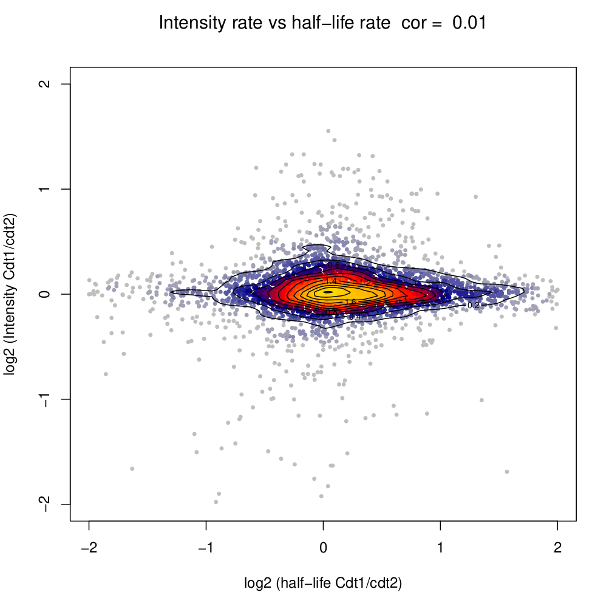

<sub>**Figure 1:** a heatscatter visualization of log2FC(half-life(cdt1/cdt2) vs log2FC(intensity(cdt1/cdt2)). Red to blue colors show high and low density respectively. Correlation between both measurement is provided (cor).</sub>

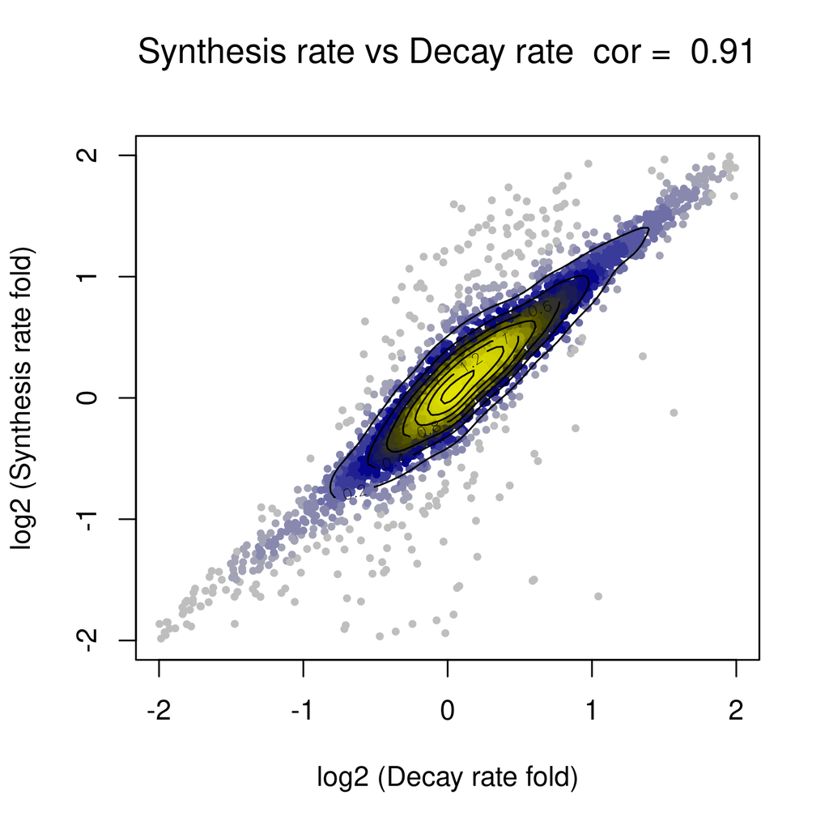

# Installation

### Dependencies

Rifi framework comparative data has the following dependencies. Make sure the requirements are satisfied by your system.

[dplyr](https://www.rdocumentation.org/packages/dplyr/versions/0.7.8) (>= 1.0.7)

[LSD](https://www.rdocumentation.org/packages/ScottKnott/versions/1.3-0/) (>= 1.3.0)

[ggplot2](https://ggplot2.tidyverse.org/) (>= 3.3.5)

[writexl](https://www.rdocumentation.org/packages/writexl/versions/1.4.0/) (>= 1.4.0)

[egg](https://www.rdocumentation.org/packages/scales/versions/0.4.1) (>= 0.4.1)

[data.table](https://www.rdocumentation.org/packages/msSPChelpR/versions/0.8.7/)(>= 0.8.7)

[ggrepel](https://www.rdocumentation.org/packages/ggrepel/versions/0.9.1/) (>= 0.9.1)

[stats](https://rdocumentation.org/packages/stats/versions/3.6.2) (>= 3.6.2)

grid (>= 3.6.2)

[rtracklayer](https://www.rdocumentation.org/packages/rtracklayer/versions/1.32.1) (>= 1.32.1)

# Troubleshooting

contact jens.georg@biologie.uni-freiburg.de or create an issue